# Chapter 02

변수의 개념을 이해하며, Input 함수에 대해 배운다.

## 변수의 개념

### 변수란?

- 변수는 값을 저장하는 메모리 공간
- 쉽게 말하면 무엇을 담는 그릇이라 생각할 수 있음.
- 변수의 이름은 자기 마음대로 지어도 됨.

#### print(100 + 200)을 입력하면 300이 출력된다. 하지만 100+200에 해당하는 코드는 한번 사용되고 없어짐

--- > 100과 200을 저장하기 위해 그릇(변수)가 필요함.  
--- > 100은 a그릇에, 200은 b그릇에 넣으면 됨.

[figure not shown]

- 이와 같이 그릇(변수) a, b를 만들어 100과 200을 대입하여 선언한 것.
- 기호 =는 오른쪽의 것을 왼쪽에 넣으라는 의미, 대입연산자라고 부름

[figure not shown]

- 이를 코드로 표현하면 아래와 같다.
- 다만 선언만 해주었기에 출력되는 것은 없음.

```python
a = 100
b = 200
```

- 변수 선언된 내용을 확인하고 싶을 땐, print()함수를 사용

```python
print(a)
print(b)
```

```
100
200
```

### 두 그릇(변수) a, b에 들어있는 값을 더해 새로운 그릇 c에 담아보기

[figure not shown]

```python
c = a + b
```

```python
print(c)
```

```
300
```

```python
print(a)
print(b)
print(c)
```

```
100
200
300
```

## 계산식( + , = )을 포함한 전체를 출력하기

- 변수와 문자열을 포함시켜 사용하여 a + b = c 를 출력해본다

[figure not shown]

```python
a = 100
b = 200
c = a+b
```

```python
print(a,"+",b,"=",c)
```

```
100 + 200 = 300
```

```python
print(a,"더하기",b,"는",c)
```

```
100 더하기 200 는 300
```

#### 변수에 문자열도 할당할 수 있음

```python
dog_name = "단추"
cat_name = "먼지"
```

```python
print(dog_name)
```

```
단추
```

```python
print(cat_name)
```

```
먼지
```

## 변수의 선언과 값의 대입

변수를 대입할 때 주의해야할 점을 살펴본다

- 대입 연산자인 =이 나오면 무조건 = 의 오른쪽 부분이 모두 계산된 후에 왼쪽으로 대입됨
- 이러한 방식이 정상적인 대입 연산자의 구조이다.
- 따라서 모든 코드에서 = 의 왼쪽에는 변수가 있어야 함

[figure not shown]

```python
num1 = 100
num2 = 50
result = num1 + 100
print(result)
```

```
200
```

- = 의 오른쪽이 모두 변수일 필요는 없음

[figure not shown]

## 올바른 값의 대입

#### 변수와 변수의 연산 / 값과 값의 연산 / 변수와 값의 연산 모두 가능하다.

- num1과 num2라는 변수를 선언해준다.

```python
num1 = 100
num2 = 50

result = num1 + num2 # 변수와 변수의 연산
result2 = num1 + 50 #  변수와 값의 연산
result3 = 100 + 50 # 값과 값의 연산
```

- result, result2, result3을 출력해본다.
- 결과는 모두 같음을 알 수 있다.

```python
print(result)
print(result2)
print(result3)
```

```
150
150
150
```

## 잘못된 값의 대입

- 대입 연산자 = 의 왼쪽이 변수가 아니라면 오류가 발생한다.
- 할당할 수 없다는 오류가 뜬다.

```python
100 = num1 + num2
```

```
  Input In [15]
    100 = num1 + num2
    ^
SyntaxError: cannot assign to literal
```

[figure not shown]

- 또, 대입 연산자 =의 왼쪽에는 변수가 한개만 존재해야 된다.

```python
num1 + num2 = result
```

```
  Input In [16]
    num1 + num2 = result
    ^
SyntaxError: cannot assign to operator
```

[figure not shown]

## 변수를 사용한 코드 출력해보기

### 사칙연산

- num1 = 100, num2 = 50
- num1과 num2를 사용하여 뺄셈 연산을 작성하며, result이라는 변수를 사용하여 결과를 넣어본다.
- 대입연산자인 =이 나오게 되면 무조건 오른쪽에 있는 부분이 계산된 후 왼쪽의 변수에 값이 대입된다.

```python
+ - * /
```

#### 덧셈 연산

- 아래와 같이 변수를 선언해준 후 print()를 사용하여 출력해보기

```python
num1 = 100
num2 = 50
result = num1 + num2
```

```python
print(num1 , "+" , num2 , "=" , result)
```

```
100 + 50 = 150
```

#### 뺄셈 연산

- 아래와 같이 변수를 선언해준 후 print()를 사용하여 출력해보기

```python
num1 = 100
num2 = 50
result = num1 - num2
```

```python
print(num1 , "-" , num2 , "=" , result)
```

```
100 - 50 = 50
```

#### 곱셈 연산

- 아래와 같이 변수를 선언해준 후 print()를 사용하여 출력해보기

```python
num1 = 100
num2 = 50
result = num1 * num2
```

```python
print(num1 , "*" , num2 , "=" , result)
```

```
100 * 50 = 5000
```

#### 나눗셈 연산

- 아래와 같이 변수를 선언해준 후 print()를 사용하여 출력해보기

```python
num1 = 100
num2 = 50
result = num1 / num2
```

```python
print(num1 , "/" , num2 , "=" , result)
```

```
100 / 50 = 2.0
```

### 문자열을 대입한 변수 사용

- 숫자와 동일하게 변수를 선언하고, 큰따옴표 또는 작은따옴표로 묶은 문자열을 대입하는 방식

```python
str1 = "난생처음"
str2 = "파이썬"
```

[figure not shown]

- print()를 사용하여 변수를 출력할 때, 콤마(,)를 사용하여 분리하여 출력하면 된다.
- 콤마(,)로 분리하면 자체적으로 한 칸 띄어쓰기가 들어간 상태로 출력이 된다. (print() 함수 기능 중 sep의 defult 값)

```python
result = str1 + str2
print(result)
```

```
난생처음파이썬
```

[figure not shown]

- 문자열을 더하는 것은 문자열을 이어주라는 의미이지만, 문자열을 빼는 연산을 진행할 경우 오류가 발생한다.
- 지원되지 않는다는 오류 메세지를 확인할 수 있다.
- 곱셈과 나눗셈도 마찬가지로 사용할 수 없다.

```python
result = str1 - str2
print(result)
```

```
---------------------------------------------------------------------------
TypeError                                 Traceback (most recent call last)
Input In [42], in <cell line: 1>()
----> 1 result = str1 - str2
      2 print(result)

TypeError: unsupported operand type(s) for -: 'str' and 'str'
```

```python
result = str1 * str2
print(result)
```

```
---------------------------------------------------------------------------
TypeError                                 Traceback (most recent call last)
Input In [45], in <cell line: 1>()
----> 1 result = str1 * str2
      2 print(result)

TypeError: can't multiply sequence by non-int of type 'str'
```

## 간단한 사칙연산(더하기, 빼기, 곱하기, 나누기)이 가능한 계산기 만들어보기

- 두 변수 num1와 num2가 주어졌을 때, 사칙연산을 계산하여 출력하도록 작성 해보시오

**답**

num1 = 100  
num2 = 100  
result1 = num1 + num2  
result2 = num1 - num2  
result3 = num1 * num2  
result4 = num1 / num2  
print(num1 , "+" , num2 , "=" , result1)  
print(num1 , "-" , num2 , "=" , result2)  
print(num1 , "*" , num2 , "=" , result3)  
print(num1 , "/" , num2 , "=" , result4)

```
100 + 100 = 200
100 - 100 = 0
100 * 100 = 10000
100 / 100 = 1.0
```

## 변수 이름 짓기

- 변수 이름은 작성자 마음이지만, 코드를 다른 사람들과 공유할때도 있고, 설명해야될 때도 있다.
- 변수 이름을 짓기 위해 몇가지 규칙이 있음

### 변수명에 대한 규칙

- 변수명은 영문과 숫자를 섞어도 된다.
- 단, 영문으로 시작해야되며, 숫자로 시작하면 안된다. 또, 숫자로만 이루어져도 안된다.

```python
a = 100
abcd = 200
abc1 = 300
q1w2e3r4 = 400

print(a)
print(abcd)
print(abc1)
print(q1w2e3r4)
```

```
100
200
300
400
```

```python
# 숫자로만 이루어져 있을 경우
123 = 456
```

```
  Input In [67]
    123 = 456
    ^
SyntaxError: cannot assign to literal
```

```python
# 숫자로 시작했을 경우
1aaa = 123
```

```
  Input In [68]
    1aaa = 123
     ^
SyntaxError: invalid syntax
```

```python
# 한국어로 변수명을 설정해도 되지만, 능한 영어로 변수명을 지어주시는 것을 권장
변수 = 123
print(변수)
```

```
123
```

### 변수명에는 언더바( _ )를 사용할 수 있다.

- 변수의 이름으로 띄어쓰기가 허용되지 않기 때문에 변수명이 길어지면 의미 파악이 어려워짐
- 이럴 때 띄어쓰기 대신 언더바( _ )를 사용
- 언더바(_)는 앞, 중간, 뒤 어느 위치에 상관없이 사용할 수 있음

```python
input_number = 100
_number = 200
_data_ = 300
__my__ = 400
_1234 = 500

print(input_number)
print(_number)
print(_data_)
print(__my__)
print(_1234)
```

```
100
200
300
400
500
```

### 변수명은 대문자와 소문자를 구분함

- 파이썬은 대문자와 소문자를 완전히 다른 것으로 취급함
- 따라서 변수명의 대문자와 소문자는 다른 변수임
- 대문자와 소문자를 섞으면 언더바 대신에 의미를 부여하기에 좋음
- 다음은 모두 올바르며, 서로 다른 변수임

```python
mynumber = 100
MYNUMBER = 200
Mynumber = 300
myNumber = 400

print(mynumber)
print(MYNUMBER)
print(Mynumber)
print(myNumber)
```

```
100
200
300
400
```

### 변수명에는 예약어를 사용할 수 없다

- 예약어란, 이미 파이썬 문법에 특별한 목적을 위해 예약되어 사용되는 단어를 말한다.
- 문법적인 기능을 수행하고 있기 때문에, 변수명으로 사용할 수 없도록 되어있다.
- 예약어를 사용하면 오류가 발생한다

```python
if = 100
```

```
  Input In [79]
    if = 100
       ^
SyntaxError: invalid syntax
```

```python
for = 200
```

```
  Input In [99]
    for = 200
        ^
SyntaxError: invalid syntax
```

[figure not shown]

```python
import keyword
print(keyword.kwlist)
print("파이썬 예약어 수: ",len(keyword.kwlist))
```

```
['False', 'None', 'True', 'and', 'as', 'assert', 'async', 'await', 'break', 'class', 'continue', 'def', 'del', 'elif', 'else', 'except', 'finally', 'for', 'from', 'global', 'if', 'import', 'in', 'is', 'lambda', 'nonlocal', 'not', 'or', 'pass', 'raise', 'return', 'try', 'while', 'with', 'yield']
파이썬 예약어 수:  35
```

### 내장함수명으로 변수명을 사용할 경우

- 파이썬에 기본적으로 내장되어 제공되는 함수들을 말한다.
- 변수명으로 함수명을 선택할 경우 오류가 발생하지는 않지만, 내장함수가 본래의 기능을 잃어버리게 되어 권장하지 않는다.

[figure not shown]

```python
print = 100
```

```python
print("Python")
```

```
---------------------------------------------------------------------------
TypeError                                 Traceback (most recent call last)
Input In [2], in <cell line: 1>()
----> 1 print("Python")

TypeError: 'int' object is not callable
```

- del()을 사용하여 변수를 삭제해주면 다시 원래의 기능으로 사용할 수 있다.

```python
del print
```

```python
print("Python")
```

```
Python
```

## 좋은 변수 이름이란?

#### 변수의 이름만 보고도 의미를 파악할 수 있어야 함

- 문법상 문제는 없지만.. 변수의 용도를 파악할 수 없는 경우

```python
a = 100
bbb = 200
asdf = 300
AA = 400
```

- 변수의 의미는 파악되지만, 너무 길어질 경우

```python
first_number_of_input_values = 100
second_number_of_input_values = 200
```

### 좋은 변수 이름은 짧으면서도 그 의미를 파악할 수 있어야 함

- 언더바 구분
- 대문자 소문자 적절하게 사용
- 의미 파악이 쉽게

```python
first_num = 100 # First Number의 약자
num_input = 200 # 입력된 숫자
inputDate = 30 # 입력된 날짜
```

## 값을 입력받는 input() 함수

### input 함수의 개념

- 키보드로 입력받도록 도와주는 함수
- 이전까지는 변수에 미리 값을 입력해 두었지만, input()함수를 사용하게되면 키보드를 통해 변수에 직접 값을 입력할 수 있다.
- input() 함수를 실행하면 입력을 받기 위한 창이 나타난다.

[figure not shown]

### input() 함수의 활용

```python
input()
```

```
100
```

```
'100'
```

- input() 함수로 값을 입력 받고, 변수에 저장하지 않으면 화면에 출력한 후 사라짐
- 따라서, input() 함수는 입력된 값을 변수에 저장하는 것이 일반적임
- input() 함수를 실행 후 값을 입력하여 Enter을 눌러 변수를 저장

```python
num1 = input()
```

```
22
```

```python
print(num1)
```

```
22
```

- 입력 시 아무 내용도 없는 창이 뜨면 답답하거나, 무엇을 입력해야하는지 알기 어려울 수 있음
- input( ) 괄호 안에 안내하는 메시지를 넣어 사용자에게 가이드할 수 있다.

```python
num2 = input("숫자 입력 --->")
```

```
숫자 입력 --->100
```

```python
print(num2)
```

```
100
```

- input()함수를 통해 입력받은 num1과 num2를 더한 값을 result 변수에 넣은 후 출력값 확인
- input() 함수를 통해 입력받은 값은 모두 문자열로 취급

```python
num1 = input()
```

```
100
```

```python
num2 = input()
```

```
200
```

```python
result = num1 + num2
```

```python
print(result)
```

```
100200
```

### 정수로 변환해주는 int() 함수

- input( )로 입력받은 값을 숫자로 사용하기 위해서는 입력받은 문자열을 다시 int() 함수를 이용하여 정수로 변환해야 함
- int( 값 )을 통해 입력된 값이 무엇이든 정수로 변환해줌

[figure not shown]

- 따옴표를 사용하여 문자열이지만 int()를 사용하여 정수로 변경

```python
int("100")
```

```
100
```

- 입력받은 값은 실수이지만 int()를 사용하여 정수로 변경

```python
int(11.7452)
```

```
11
```

```python
int(3.14)
```

```
3
```

### num1, num2를 입력받고, 이를 더해주는 코드를 작성하여 출력하기

- input() 와 int() 를 사용하여 num1과 num2 값을 정수로 입력받는다.
- result에 num1과 num2를 더한 값을 저장한다.
- print()를 사용하여 result 값을 확인한다.

**접기/펼치기**

num1 = int(input("num1 ==>"))  
num2 = int(input("num2 ==>"))  
result = num1 + num2  
print(result)

```
num1 ==>100
num2 ==>200
300
```

### 사용자에게 이름과 전화번호를 입력받아 출력하기

- input() 를 사용하여 메세지로 "이름: ", "전화번호: "가 출력되도록 하며, 이름과 전화번호를 각각 입력받는다.
- print() 를 사용하여 "제 이름은 [변수]이고, 전화번호는 [변수]입니다."가 출력되도록 작성한다.

**답**

user_name = input("이름:")  
user_phone = input("전화번호: ")  
print("제 이름은 ", user_name, "이고, 연락처는", user_phone, "입니다")

```
이름:김ㅇㅇ
전화번호: 010-0000-0000
제 이름은  김ㅇㅇ 이고, 연락처는 010-0000-0000 입니다
```

### 택배 배송 정보 입력 시스템

- 택배를 보낼 때, 받는 사람과 주소를 입력한 후 택배의 무게를 측정하여 입력된다.
- 택배 무게는 그램(g)당 5원이며, 자동으로 계산된다.
- 택배 정보를 입력받아 배송비와 함께 출력되도록 코드를 작성해보자

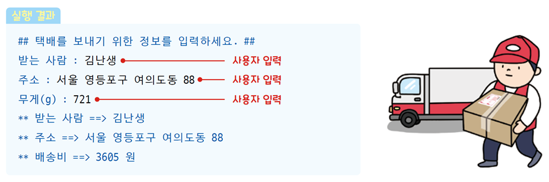

**접기/펼치기**

print("## 택배를 보내기 위한 정보를 입력하세요. ##")  
person_name = input("받는 사람 : ")  
person_addr = input("주소 : ")  
weight = int(input("무게(g) : "))  
print("** 받는 사람 ==>", person_name)  
print("** 주소 =>", person_addr)  
print("** 배송비 ==>", weight*5, "원")

### 숫자를 입력하는 계산기 만들기

- 키보드로 2개의 숫자를 입력하면 두 숫자의 덧셈, 뺄셈, 곱셈, 나눗셈, 나머지, 제곱을 계산하는 계산기를 만들어 보자

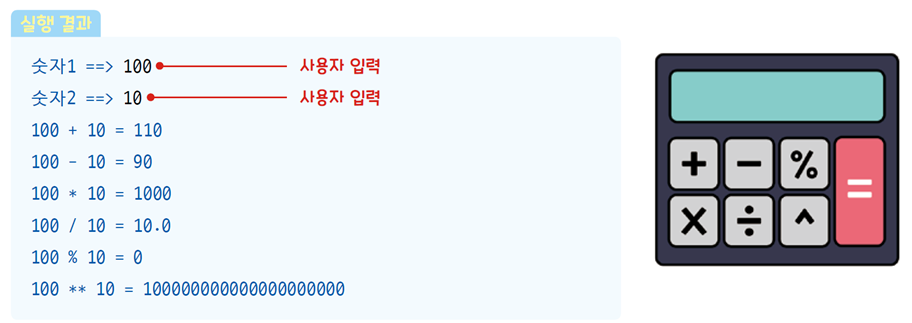

**접기/펼치기**

num1 = int(input("숫자1 ==>"))  
num2 = int(input("숫자2 ==>"))  
result1 = num1 + num2  
result2 = num1 - num2  
result3 = num1 * num2  
result4 = num1 / num2  
result5 = num1 % num2  
result6 = num1 ** num2 print(num1 , "+" , num2 , "=" , result1)  
print(num1 , "-" , num2 , "=" , result2)  
print(num1 , "*" , num2 , "=" , result3)  
print(num1 , "/" , num2 , "=" , result4)  
print(num1 , "%" , num2 , "=" , result5)  
print(num1 , "**" , num2 , "=" , result6)